# 2023_DCR_MR_Grayling

2024-2-12

# Tables and Plots

## Area and Size Designations

New Area Designations

| area | Section_Start | Section_End | R | M | C | n.sections |
| --- | --- | --- | --- | --- | --- | --- |
| A | 1 | 5 | 8 | 164 | 248 | 5 |
| B | 6 | 10 | 10 | 189 | 187 | 5 |
| C | 11 | 14 | 7 | 120 | 181 | 4 |
| D | 15 | 18 | 13 | 113 | 141 | 4 |
| E | 19 | 22 | 13 | 202 | 330 | 4 |

Size Designation using FL~TL regression

| Size_Class | Inches | MM_Conversion | FL_equivalent |
| --- | --- | --- | --- |
| 12” and greater | 12 | 305 | 284 |
| 13” and greater | 13 | 330 | 307 |
| 14” and greater | 14 | 356 | 331 |
| 15” and greater | 15 | 381 | 355 |
| 16” and greater | 16 | 406 | 379 |
| 17” and greater | 17 | 432 | 403 |
| 18” and greater | 18 | 457 | 427 |
| 19” and greater | 19 | 483 | 451 |
| 20” and greater | 20 | 508 | 474 |

## Crew Fish Counts Table

| Crew | Total | Event1 | Event2 | N.recaps | Days_Fished | AvgDay | Recap_rate |
| --- | --- | --- | --- | --- | --- | --- | --- |
| JRS | 435 | 230 | 205 | 19 | 11 | 39.54545 | 0.0926829 |
| LG | 416 | 179 | 237 | 6 | 13 | 32.00000 | 0.0253165 |
| BC | 377 | 121 | 256 | 9 | 10 | 37.70000 | 0.0351562 |
| CW | 369 | 161 | 208 | 14 | 10 | 36.90000 | 0.0673077 |
| MDS | 367 | 185 | 182 | 8 | 11 | 33.36364 | 0.0439560 |
| LW | 357 | 194 | 163 | 9 | 11 | 32.45455 | 0.0552147 |
| MW | 317 | 135 | 182 | 8 | 10 | 31.70000 | 0.0439560 |
| HP | 240 | 0 | 240 | 10 | 5 | 48.00000 | 0.0416667 |
| AE | 236 | 11 | 225 | 11 | 6 | 39.33333 | 0.0488889 |
| MRM | 202 | 0 | 202 | 5 | 5 | 40.40000 | 0.0247525 |
| MA | 132 | 91 | 41 | 0 | 4 | 33.00000 | 0.0000000 |
| EM | 105 | 105 | 0 | 0 | 5 | 21.00000 | NaN |
| BB | 86 | 53 | 33 | 3 | 4 | 21.50000 | 0.0909091 |
| TM | 40 | 40 | 0 | 0 | 2 | 20.00000 | NaN |
| KW | 29 | 29 | 0 | 0 | 1 | 29.00000 | NaN |
| AB | 27 | 27 | 0 | 0 | 1 | 27.00000 | NaN |
| MR | 15 | 15 | 0 | 0 | 1 | 15.00000 | NaN |

## Movement of Recaps

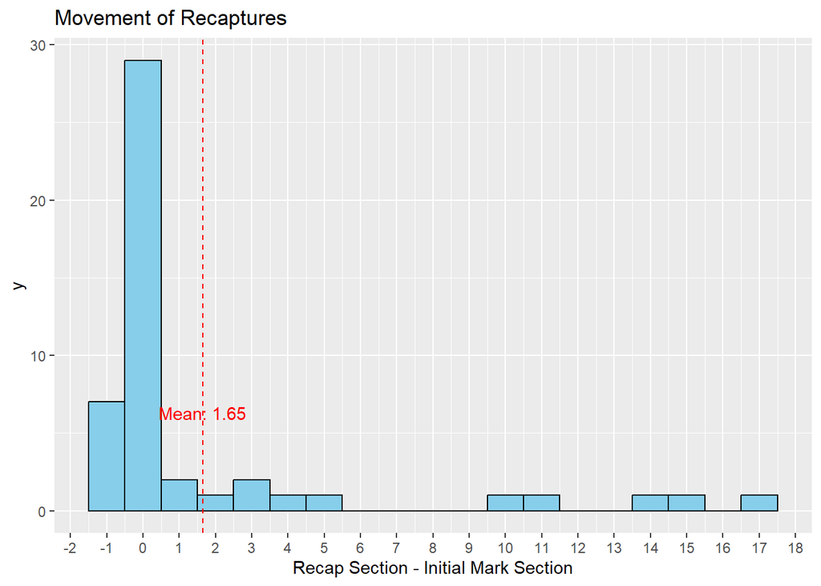

## Length Distributions Overall

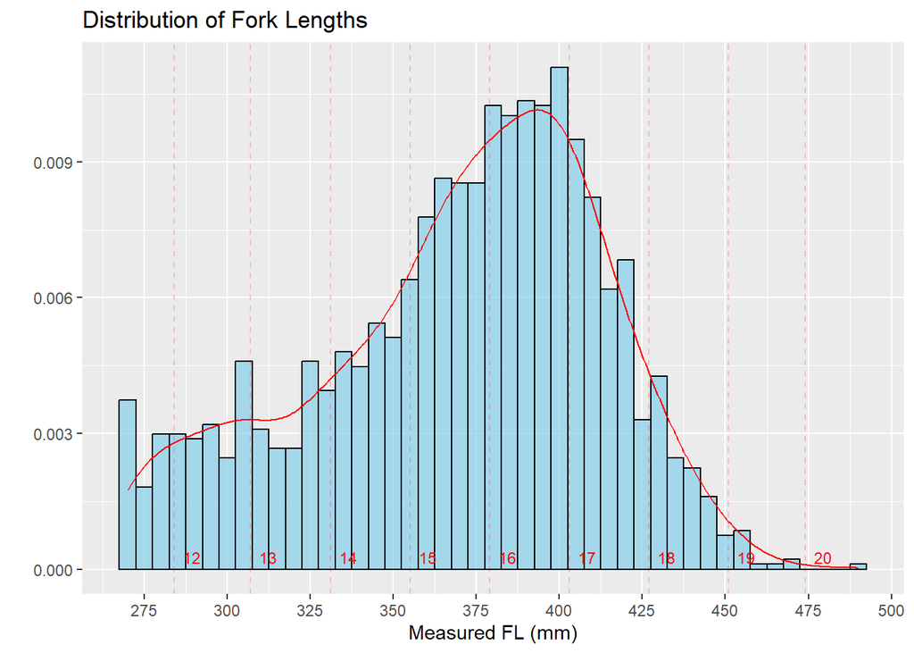

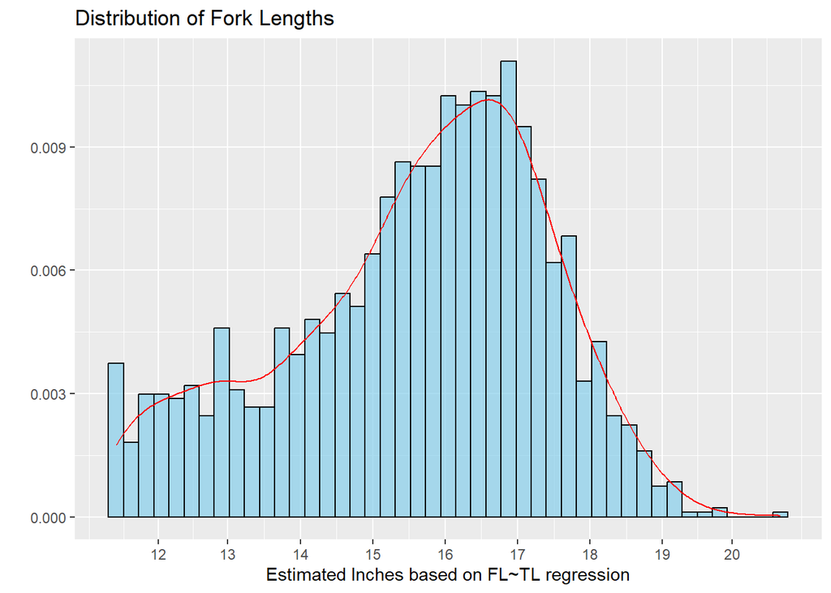

## Length Distribution By Area

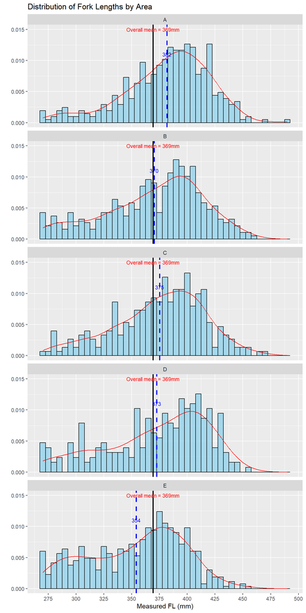

## Length by Map_Section

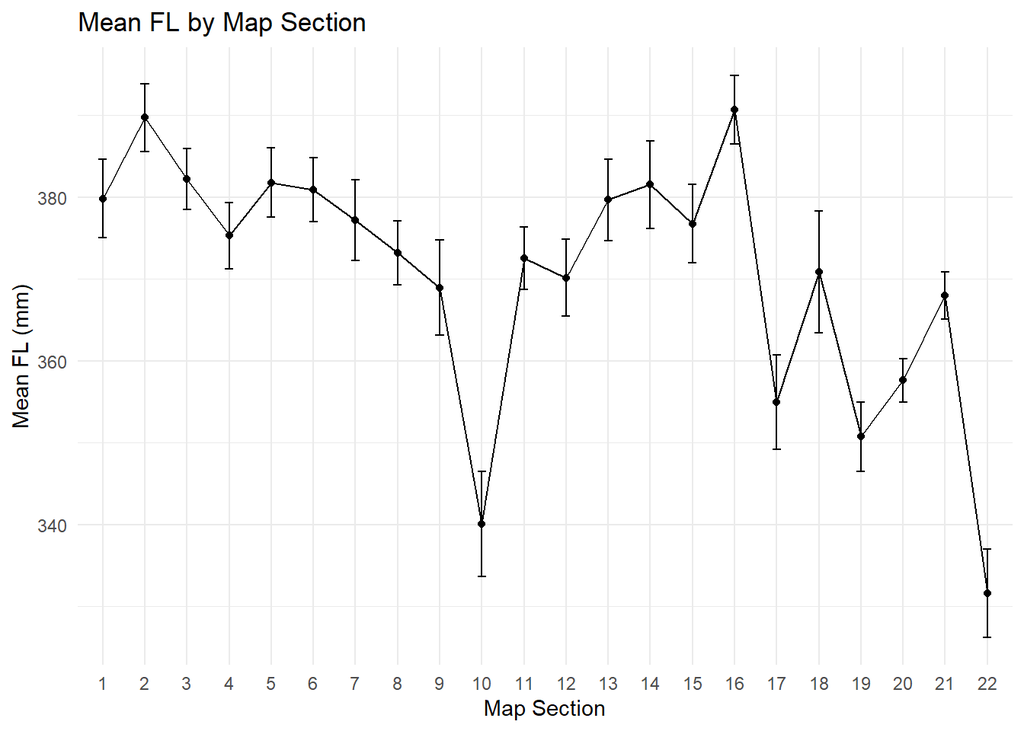

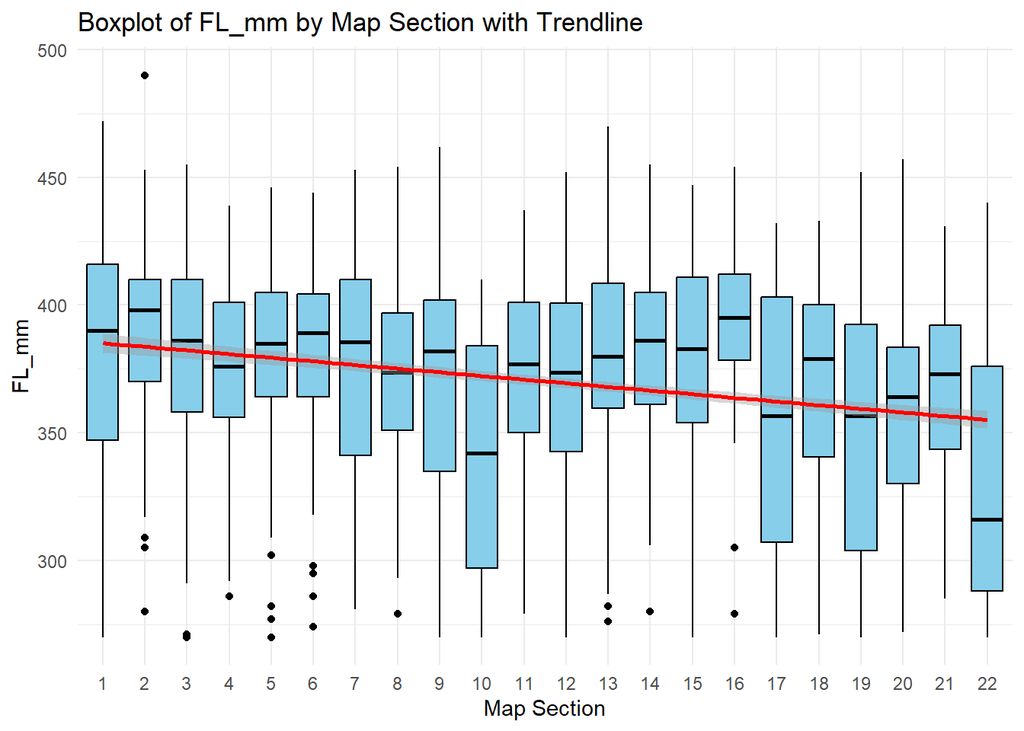

# Abundance Estimates For Each Size Class

## **All data (Forklength $\ge$ 270mm)**

### KS-Tests

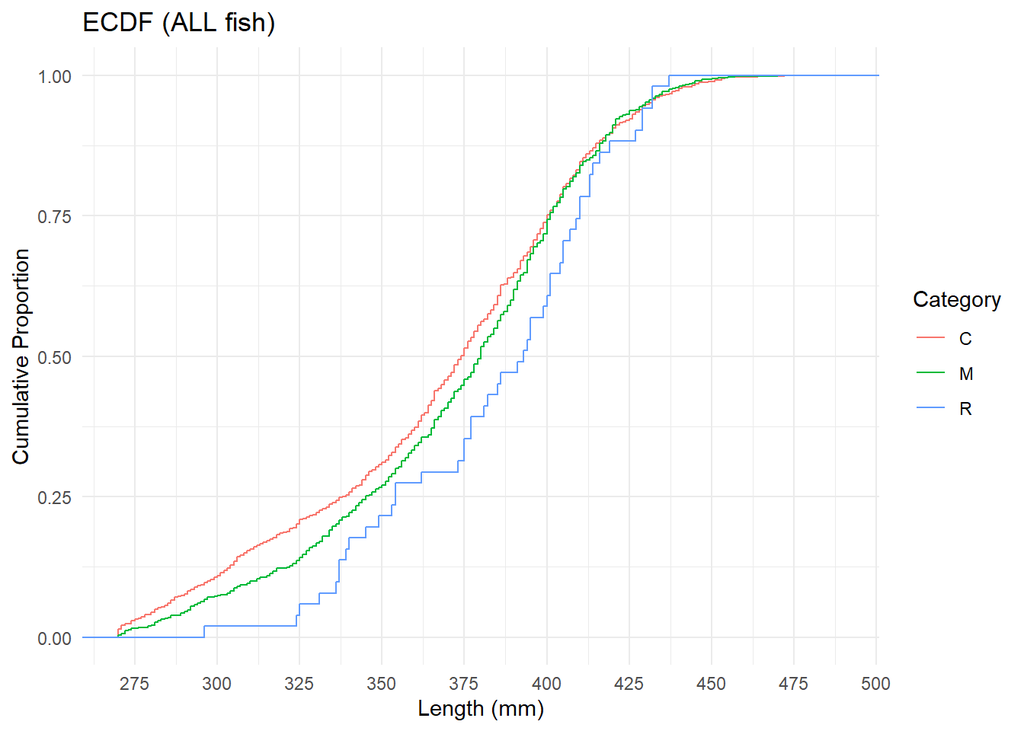

KS-tests for size selective sampling

|  | M_vs_R | C_vs_R | M_vs_C |
| --- | --- | --- | --- |
| D statistic | 0.154 | 0.19 | 0.067 |
| p-value | 0.203 | 0.06 | 0.034 |
| Decision | Fail to Reject H0 | Fail to Reject H0 | Reject H0 |

### CHI SQ TESTS

#### Test for Complete Mixing

Test for complete mixing

|  | Area Recaptured A | Area Recaptured B | Area Recaptured C | Area Recaptured D | Area Recaptured E | n1_m2 |
| --- | --- | --- | --- | --- | --- | --- |
| A | 6 | 0 | 1 | 0 | 2 | 155 |
| B | 2 | 6 | 1 | 1 | 1 | 178 |
| C | 0 | 2 | 4 | 0 | 0 | 114 |
| D | 0 | 0 | 0 | 12 | 1 | 100 |
| E | 0 | 0 | 0 | 0 | 9 | 193 |

```
##
##  Pearson's Chi-squared test
##
## data:  Mixtable
## X-squared = 121.4, df = 20, p-value < 2.2e-16
```

```
## [1] "Reject H0"
```

#### Test for equal probability of capture during Event 1 (H0 = Every fish has an equal probability of being captured and marked during event 1)

Test for equal probability of caputre during Event 1

|  | A | B | C | D | E |
| --- | --- | --- | --- | --- | --- |
| m2 | 8 | 8 | 6 | 13 | 13 |
| n2_m2 | 240 | 177 | 174 | 128 | 317 |

```
##
##  Pearson's Chi-squared test
##
## data:  ProbE1
## X-squared = 9.1979, df = 4, p-value = 0.05634
```

```
## [1] "Fail to Reject H0"
```

#### Test for equal probability of capture during Event 2 (H0 = Every fish has an equal probability of being captured and marked during event 2)

Test for equal probability of caputre during Event 2

|  | A | B | C | D | E |
| --- | --- | --- | --- | --- | --- |
| m2 | 9 | 11 | 6 | 13 | 9 |
| n1_m2 | 153 | 178 | 114 | 100 | 193 |

```
##
##  Pearson's Chi-squared test
##
## data:  ProbE2
## X-squared = 7.0716, df = 4, p-value = 0.1322
```

```
## [1] "Fail to Reject H0"
```

### Abundance Estimate (All fish)

Bailey modification: $\hat{N} = \frac{M (C +1)}{(R +1)}$ and $Var(\hat{N}) = \frac{M^2(C+1)(C-R)}{(R+1)^2(R+2)}$

| Abundance.Estimate | Variance | Lower95_CI | upper95_CI |
| --- | --- | --- | --- |
| 16487.38 | 4883807 | 12155.91 | 20818.85 |

## **12+ (ForkLength $\ge$ 283.6315 FL)**

### KS-Tests

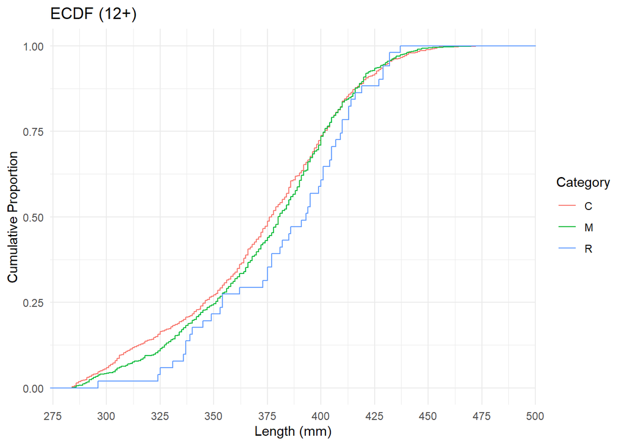

KS-tests for size selective sampling

|  | M_vs_R | C_vs_R | M_vs_C |
| --- | --- | --- | --- |
| D statistic | 0.143 | 0.162 | 0.054 |
| p-value | 0.284 | 0.157 | 0.157 |
| Decision | Fail to Reject H0 | Fail to Reject H0 | Fail to Reject H0 |

### CHI SQ TESTS

#### Test for Complete Mixing

Test for complete mixing

|  | Area Recaptured A | Area Recaptured B | Area Recaptured C | Area Recaptured D | Area Recaptured E | n1_m2 |
| --- | --- | --- | --- | --- | --- | --- |
| A | 6 | 0 | 1 | 0 | 2 | 153 |
| B | 2 | 6 | 1 | 1 | 1 | 172 |
| C | 0 | 2 | 4 | 0 | 0 | 112 |
| D | 0 | 0 | 0 | 12 | 1 | 95 |
| E | 0 | 0 | 0 | 0 | 9 | 183 |

```
##
##  Pearson's Chi-squared test
##
## data:  Mixtable
## X-squared = 122.11, df = 20, p-value < 2.2e-16
```

```
## [1] "Reject H0"
```

#### Test for equal probability of capture during Event 1 (H0 = Every fish has an equal probability of being captured and marked during event 1)

Test for equal probability of caputre during Event 1

|  | A | B | C | D | E |
| --- | --- | --- | --- | --- | --- |
| m2 | 8 | 8 | 6 | 13 | 13 |
| n2_m2 | 235 | 163 | 168 | 119 | 293 |

```
##
##  Pearson's Chi-squared test
##
## data:  ProbE1
## X-squared = 9.6764, df = 4, p-value = 0.04625
```

```
## [1] "Reject H0"
```

#### Test for equal probability of capture during Event 2 (H0 = Every fish has an equal probability of being captured and marked during event 2)

Test for equal probability of caputre during Event 2

|  | A | B | C | D | E |
| --- | --- | --- | --- | --- | --- |
| m2 | 9 | 11 | 6 | 13 | 9 |
| n1_m2 | 151 | 172 | 112 | 95 | 183 |

```
##
##  Pearson's Chi-squared test
##
## data:  ProbE2
## X-squared = 7.3038, df = 4, p-value = 0.1207
```

```
## [1] "Fail to Reject H0"
```

### Abundance Estimate (12+)

| Abundance.Estimate | Variance | Lower95_CI | Upper95_CI |
| --- | --- | --- | --- |
| 15113.27 | 4092066 | 11148.41 | 19078.12 |

## **13+ (ForkLength $\ge$ 307.4735 FL)**

### KS-Tests

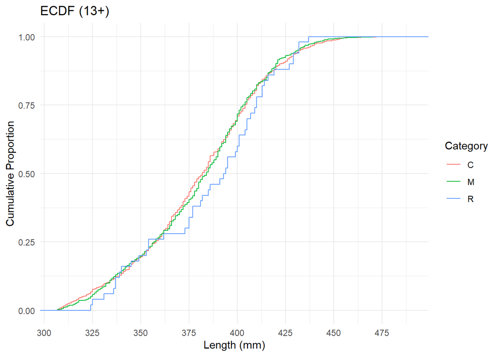

KS-tests for size selective sampling

|  | M_vs_R | C_vs_R | M_vs_C |
| --- | --- | --- | --- |
| D statistic | 0.129 | 0.135 | 0.037 |
| p-value | 0.413 | 0.349 | 0.643 |
| Decision | Fail to Reject H0 | Fail to Reject H0 | Fail to Reject H0 |

### CHI SQ TESTS

#### Test for Complete Mixing

Test for complete mixing

|  | Area Recaptured A | Area Recaptured B | Area Recaptured C | Area Recaptured D | Area Recaptured E | n1_m2 |
| --- | --- | --- | --- | --- | --- | --- |
| A | 6 | 0 | 1 | 0 | 2 | 150 |
| B | 2 | 6 | 1 | 1 | 1 | 159 |
| C | 0 | 2 | 4 | 0 | 0 | 109 |
| D | 0 | 0 | 0 | 11 | 1 | 87 |
| E | 0 | 0 | 0 | 0 | 9 | 165 |

```
##
##  Pearson's Chi-squared test
##
## data:  Mixtable
## X-squared = 117.3, df = 20, p-value = 8.991e-16
```

```
## [1] "Reject H0"
```

#### Test for equal probability of capture during Event 1 (H0 = Every fish has an equal probability of being captured and marked during event 1)

Test for equal probability of caputre during Event 1

|  | A | B | C | D | E |
| --- | --- | --- | --- | --- | --- |
| m2 | 8 | 8 | 6 | 12 | 13 |
| n2_m2 | 221 | 152 | 158 | 109 | 241 |

```
##
##  Pearson's Chi-squared test
##
## data:  ProbE1
## X-squared = 7.7792, df = 4, p-value = 0.1
```

```
## [1] "Fail to Reject H0"
```

#### Test for equal probability of capture during Event 2 (H0 = Every fish has an equal probability of being captured and marked during event 2)

Test for equal probability of caputre during Event 2

|  | A | B | C | D | E |
| --- | --- | --- | --- | --- | --- |
| m2 | 9 | 11 | 6 | 12 | 9 |
| n1_m2 | 148 | 159 | 109 | 87 | 165 |

```
##
##  Pearson's Chi-squared test
##
## data:  ProbE2
## X-squared = 6.0457, df = 4, p-value = 0.1958
```

```
## [1] "Fail to Reject H0"
```

### Abundance Estimate (13+)

| Abundance.Estimate | Variance | Lower95_CI | Upper95_CI |
| --- | --- | --- | --- |
| 13102.82 | 3120947 | 9640.248 | 16565.4 |

## **14+ (ForkLength $\ge$ 331.3154 FL)**

### KS-Tests

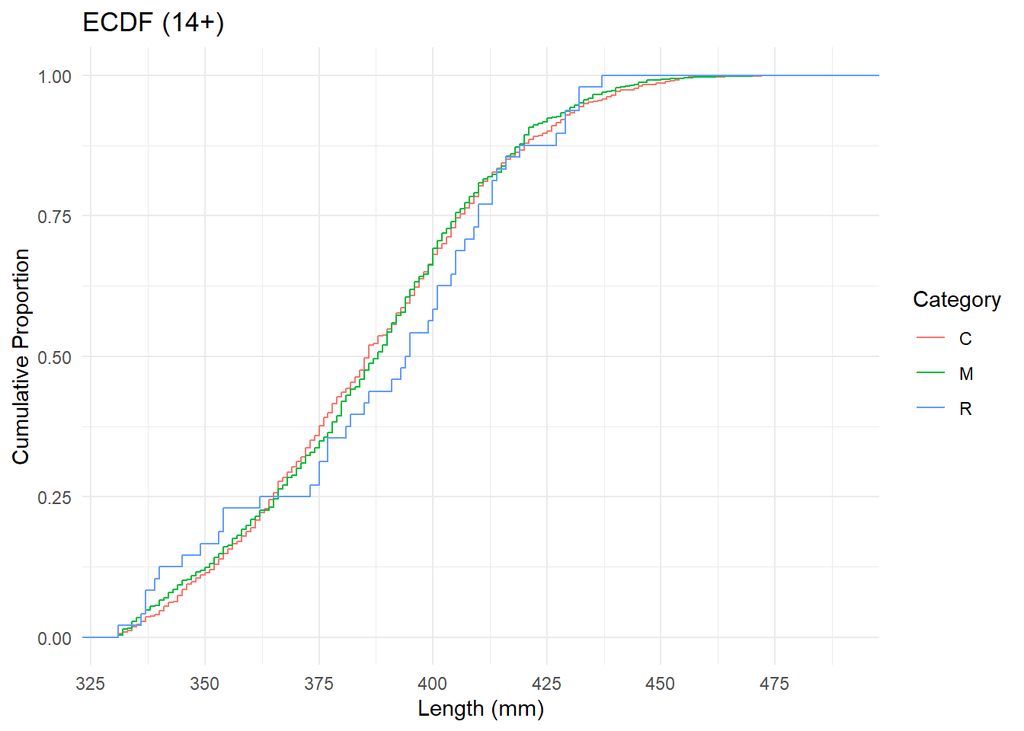

KS-tests for size selective sampling

|  | M_vs_R | C_vs_R | M_vs_C |
| --- | --- | --- | --- |
| D statistic | 0.115 | 0.118 | 0.036 |
| p-value | 0.597 | 0.546 | 0.722 |
| Decision | Fail to Reject H0 | Fail to Reject H0 | Fail to Reject H0 |

### CHI SQ TESTS

#### Test for Complete Mixing

Test for complete mixing

|  | Area Recaptured A | Area Recaptured B | Area Recaptured C | Area Recaptured D | Area Recaptured E | n1_m2 |
| --- | --- | --- | --- | --- | --- | --- |
| A | 6 | 0 | 1 | 0 | 2 | 141 |
| B | 2 | 6 | 1 | 1 | 1 | 145 |
| C | 0 | 2 | 4 | 0 | 0 | 100 |
| D | 0 | 0 | 0 | 11 | 1 | 80 |
| E | 0 | 0 | 0 | 0 | 6 | 146 |

```
##
##  Pearson's Chi-squared test
##
## data:  Mixtable
## X-squared = 108.94, df = 20, p-value = 3.059e-14
```

```
## [1] "Reject H0"
```

#### Test for equal probability of capture during Event 1 (H0 = Every fish has an equal probability of being captured and marked during event 1)

Test for equal probability of caputre during Event 1

|  | A | B | C | D | E |
| --- | --- | --- | --- | --- | --- |
| m2 | 8 | 8 | 6 | 12 | 11 |
| n2_m2 | 213 | 139 | 145 | 97 | 204 |

```
##
##  Pearson's Chi-squared test
##
## data:  ProbE1
## X-squared = 8.8091, df = 4, p-value = 0.06605
```

```
## [1] "Fail to Reject H0"
```

#### Test for equal probability of capture during Event 2 (H0 = Every fish has an equal probability of being captured and marked during event 2)

Test for equal probability of caputre during Event 2

|  | A | B | C | D | E |
| --- | --- | --- | --- | --- | --- |
| m2 | 9 | 11 | 6 | 12 | 6 |
| n1_m2 | 139 | 145 | 100 | 80 | 146 |

```
##
##  Pearson's Chi-squared test
##
## data:  ProbE2
## X-squared = 8.0376, df = 4, p-value = 0.09021
```

```
## [1] "Fail to Reject H0"
```

### Abundance Estimate (14+)

| Abundance.Estimate | Variance | Lower95_CI | Upper95_CI |
| --- | --- | --- | --- |
| 11339.43 | 2422880 | 8288.571 | 14390.29 |

## **15+ (ForkLength $\ge$ 355.1573 FL)**

### KS-Tests

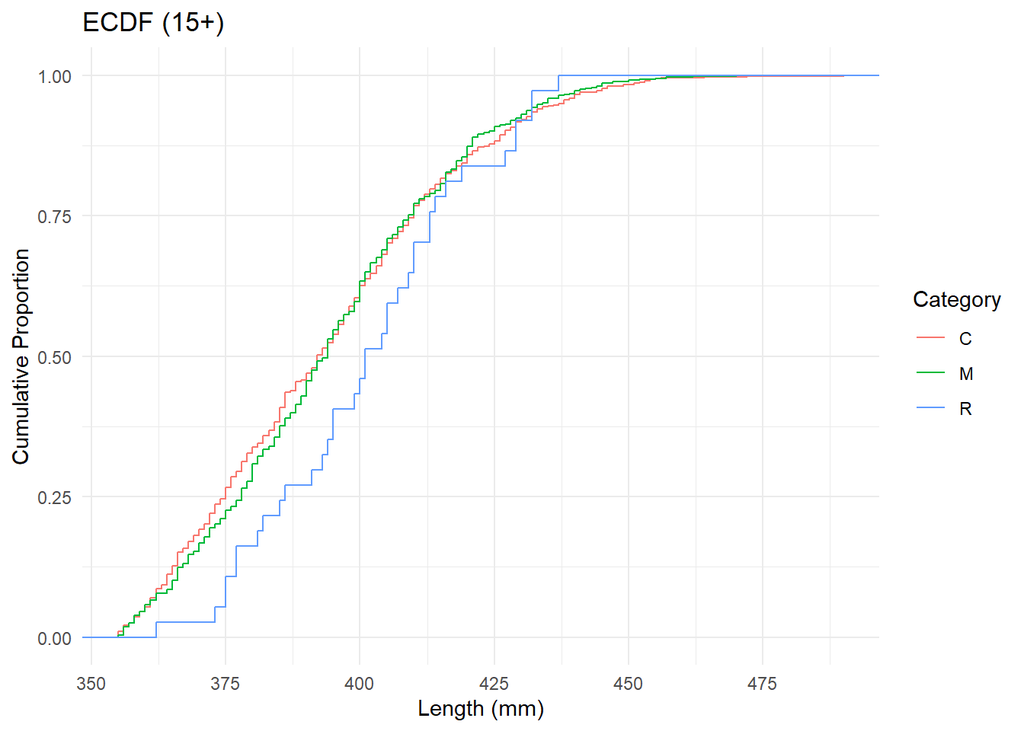

KS-tests for size selective sampling

|  | M_vs_R | C_vs_R | M_vs_C |
| --- | --- | --- | --- |
| D statistic | 0.195 | 0.205 | 0.052 |
| p-value | 0.145 | 0.102 | 0.358 |
| Decision | Fail to Reject H0 | Fail to Reject H0 | Fail to Reject H0 |

### CHI SQ TESTS

#### Test for Complete Mixing

Test for complete mixing

|  | Area Recaptured A | Area Recaptured B | Area Recaptured C | Area Recaptured D | Area Recaptured E | n1_m2 |
| --- | --- | --- | --- | --- | --- | --- |
| A | 6 | 0 | 1 | 0 | 2 | 118 |
| B | 2 | 6 | 1 | 0 | 1 | 121 |
| C | 0 | 1 | 3 | 0 | 0 | 88 |
| D | 0 | 0 | 0 | 9 | 0 | 70 |
| E | 0 | 0 | 0 | 0 | 3 | 119 |

```
##
##  Pearson's Chi-squared test
##
## data:  Mixtable
## X-squared = 95.225, df = 20, p-value = 8.922e-12
```

```
## [1] "Reject H0"
```

#### Test for equal probability of capture during Event 1 (H0 = Every fish has an equal probability of being captured and marked during event 1)

Test for equal probability of caputre during Event 1

|  | A | B | C | D | E |
| --- | --- | --- | --- | --- | --- |
| m2 | 8 | 7 | 5 | 9 | 6 |
| n2_m2 | 189 | 116 | 123 | 88 | 167 |

```
##
##  Pearson's Chi-squared test
##
## data:  ProbE1
## X-squared = 5.5116, df = 4, p-value = 0.2387
```

```
## [1] "Fail to Reject H0"
```

#### Test for equal probability of capture during Event 2 (H0 = Every fish has an equal probability of being captured and marked during event 2)

Test for equal probability of caputre during Event 2

|  | A | B | C | D | E |
| --- | --- | --- | --- | --- | --- |
| m2 | 9 | 10 | 4 | 9 | 3 |
| n1_m2 | 116 | 121 | 88 | 70 | 119 |

```
##
##  Pearson's Chi-squared test
##
## data:  ProbE2
## X-squared = 7.59, df = 4, p-value = 0.1078
```

```
## [1] "Fail to Reject H0"
```

### Abundance Estimate (15+)

| Abundance.Estimate | Variance | Lower95_CI | Upper95_CI |
| --- | --- | --- | --- |
| 10454.5 | 2654773 | 7260.979 | 13648.02 |

## **16+ (ForkLength $\ge$ 378.9992 FL)**

### KS-Tests

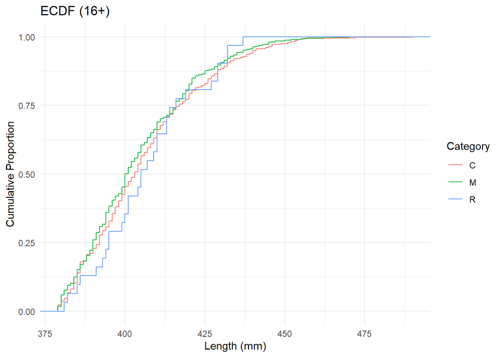

KS-tests for size selective sampling

|  | M_vs_R | C_vs_R | M_vs_C |
| --- | --- | --- | --- |
| D statistic | 0.147 | 0.115 | 0.059 |
| p-value | 0.559 | 0.831 | 0.424 |
| Decision | Fail to Reject H0 | Fail to Reject H0 | Fail to Reject H0 |

### CHI SQ TESTS

#### Test for Complete Mixing

Test for complete mixing

|  | Area Recaptured A | Area Recaptured B | Area Recaptured C | Area Recaptured D | Area Recaptured E | n1_m2 |
| --- | --- | --- | --- | --- | --- | --- |
| A | 5 | 0 | 1 | 0 | 0 | 93 |
| B | 2 | 6 | 1 | 0 | 0 | 84 |
| C | 0 | 1 | 3 | 0 | 0 | 64 |
| D | 0 | 0 | 0 | 7 | 0 | 58 |
| E | 0 | 0 | 0 | 0 | 3 | 77 |

```
##
##  Pearson's Chi-squared test
##
## data:  Mixtable
## X-squared = 82.838, df = 20, p-value = 1.288e-09
```

```
## [1] "Reject H0"
```

#### Test for equal probability of capture during Event 1 (H0 = Every fish has an equal probability of being captured and marked during event 1)

Test for equal probability of caputre during Event 1

|  | A | B | C | D | E |
| --- | --- | --- | --- | --- | --- |
| m2 | 7 | 7 | 5 | 7 | 3 |
| n2_m2 | 136 | 88 | 83 | 64 | 93 |

```
##
##  Pearson's Chi-squared test
##
## data:  ProbE1
## X-squared = 3.9836, df = 4, p-value = 0.4082
```

```
## [1] "Fail to Reject H0"
```

#### Test for equal probability of capture during Event 2 (H0 = Every fish has an equal probability of being captured and marked during event 2)

Test for equal probability of caputre during Event 2

|  | A | B | C | D | E |
| --- | --- | --- | --- | --- | --- |
| m2 | 6 | 9 | 4 | 7 | 3 |
| n1_m2 | 91 | 84 | 64 | 58 | 77 |

```
##
##  Pearson's Chi-squared test
##
## data:  ProbE2
## X-squared = 3.8467, df = 4, p-value = 0.4271
```

```
## [1] "Fail to Reject H0"
```

### Abundance Estimate (16+)

| Abundance.Estimate | Variance | Lower95_CI | Upper95_CI |
| --- | --- | --- | --- |
| 6277.5 | 1117110 | 4205.909 | 8349.091 |

# Results Table

## MR- Subset

| size_class | M | C | R | Nhat | Variance_Nhat | L95CI | U95CI | CV | RP_95 | RP_90 |
| --- | --- | --- | --- | --- | --- | --- | --- | --- | --- | --- |
| 270mm+ | 788 | 1087 | 51 | 16487 | 4883807 | 12156 | 20819 | 0.13404 | 0.263 | 0.221 |
| 12” and greater | 763 | 1029 | 51 | 15113 | 4092066 | 11148 | 19078 | 0.13385 | 0.262 | 0.221 |
| 13” and greater | 717 | 931 | 50 | 13103 | 3120947 | 9640 | 16565 | 0.13483 | 0.264 | 0.222 |
| 14” and greater | 656 | 846 | 48 | 11339 | 2422880 | 8289 | 14390 | 0.13727 | 0.269 | 0.226 |
| 15” and greater | 551 | 720 | 37 | 10454 | 2654773 | 7261 | 13648 | 0.15585 | 0.305 | 0.257 |
| 16” and greater | 405 | 495 | 31 | 6278 | 1117110 | 4206 | 8349 | 0.16837 | 0.330 | 0.278 |

## Proportional Allocation

| size_class | p | var_p | Nhat_p | var_Nhat_p | L95CI_p | U95CI_p | CV | RP_95 | RP_90 |
| --- | --- | --- | --- | --- | --- | --- | --- | --- | --- |
| 270mm+ | 1.00 | 0.0000000 | 16487 | 4883807 | 12156 | 20819 | 0.13404 | 0.263 | 0.221 |
| 12” and greater | 0.95 | 0.0000238 | 15737 | 4455811 | 11600 | 19874 | 0.13413 | 0.263 | 0.221 |
| 13” and greater | 0.88 | 0.0000595 | 14445 | 3764438 | 10642 | 18247 | 0.13432 | 0.263 | 0.222 |
| 14” and greater | 0.80 | 0.0000887 | 13143 | 3127078 | 9677 | 16609 | 0.13455 | 0.264 | 0.222 |
| 15” and greater | 0.68 | 0.0001200 | 11154 | 2267362 | 8203 | 14106 | 0.13500 | 0.265 | 0.223 |
| 16” and greater | 0.48 | 0.0001368 | 7855 | 1145060 | 5758 | 9952 | 0.13623 | 0.267 | 0.225 |

## Proportional with Discrete Size Bins

| size_class | n_k | p_k | var_p | Nhat_p | var_Nhat_p | L95CI_p | U95CI_p | CV | RP_95 | RP_90 |
| --- | --- | --- | --- | --- | --- | --- | --- | --- | --- | --- |
| 0-12 | 83 | 0.05 | 0.0000238 | 750 | 16473 | 499 | 1002 | 0.17107 | 0.335 | 0.282 |
| 12-13 | 143 | 0.08 | 0.0000396 | 1293 | 40598 | 898 | 1688 | 0.15588 | 0.306 | 0.257 |
| 13-14 | 144 | 0.08 | 0.0000399 | 1302 | 41087 | 904 | 1699 | 0.15573 | 0.305 | 0.257 |
| 14-15 | 220 | 0.12 | 0.0000582 | 1989 | 86580 | 1412 | 2565 | 0.14797 | 0.290 | 0.244 |
| 15-16 | 365 | 0.20 | 0.0000878 | 3299 | 219006 | 2382 | 4217 | 0.14184 | 0.278 | 0.234 |
| 16-17 | 449 | 0.25 | 0.0001018 | 4059 | 323112 | 2944 | 5173 | 0.14006 | 0.275 | 0.231 |
| 17-18 | 301 | 0.17 | 0.0000756 | 2721 | 153174 | 1954 | 3488 | 0.14385 | 0.282 | 0.237 |
| 18-19 | 102 | 0.06 | 0.0000290 | 922 | 23003 | 625 | 1219 | 0.16450 | 0.322 | 0.271 |
| 19+ | 17 | 0.01 | 0.0000051 | 154 | 1776 | 71 | 236 | 0.27427 | 0.538 | 0.453 |

```
##            0-12     12-13     13-14      14-15    15-16     16-17      17-18
## m2     2.568266  4.339483  3.763838   5.535055   9.9631  10.67159   7.837638
## n2_m2 55.431734 93.660517 81.236162 119.464945 215.0369 230.32841 169.162362
##           18-19        19+
## m2     2.789668  0.5313653
## n2_m2 60.210332 11.4686347
```

```
##            0-12    12-13     13-14     14-15      15-16     16-17      17-18
## m2     1.526718  2.80916  3.725191  6.412214   8.916031  13.37405   8.244275
## n1_m2 23.473282 43.19084 57.274809 98.587786 137.083969 205.62595 126.755725
##           18-19       19+
## m2     2.687023 0.3053435
## n1_m2 41.312977 4.6946565
```

```
##
##  Pearson's Chi-squared test
##
## data:  size_binE1_SML
## X-squared = 2.9972, df = 2, p-value = 0.2234
```

```
##
##  Pearson's Chi-squared test
##
## data:  size_binE2_SML
## X-squared = 4.1875, df = 2, p-value = 0.1232
```

```
##       0-12 12+
## m2       0  48
## n2_m2   58 978
```

```
##            0-12       12+
## m2     2.568266  45.43173
## n2_m2 55.431734 980.56827
```

```
##
##  Pearson's Chi-squared test with Yates' continuity correction
##
## data:  size_binE1_12
## X-squared = 1.8413, df = 1, p-value = 0.1748
```

```
##       0-12 12+
## m2       0  48
## n1_m2   25 713
```

```
##            0-12       12+
## m2     1.526718  46.47328
## n1_m2 23.473282 714.52672
```

```
##
##  Pearson's Chi-squared test with Yates' continuity correction
##
## data:  size_binE2_12
## X-squared = 0.75953, df = 1, p-value = 0.3835
```